# Airbnb_Analise slides

## Análise de Dados - Airbnb

### Por: Felippe Galdino Silva

## 1. Exploração dos dados (EDA)

### Inspecionando os datasets:

#### Reviews

|  | listing_id | id | date | reviewer_id | reviewer_name | comments |
| --- | --- | --- | --- | --- | --- | --- |
| 0 | 17878 | 64852 | 2010-07-15 | 135370 | Tia | This apartment is in a perfect location -- two... |
| 1 | 17878 | 76744 | 2010-08-11 | 10206 | Mimi | we had a really great experience staying in Ma... |
| 2 | 17878 | 91074 | 2010-09-06 | 80253 | Jan | Staying in Max appartment is like living in a ... |
| 3 | 17878 | 137528 | 2010-11-12 | 230449 | Orene | In general very good and reasonable price.\r\n... |
| 4 | 17878 | 147594 | 2010-12-01 | 219338 | David | The apt was nice and in a great location only ... |
| 5 | 17878 | 152368 | 2010-12-12 | 266847 | Armi | At Copacabana apartment is best the situation ... |
| 6 | 17878 | 155565 | 2010-12-19 | 243287 | Jonathan | A great apartment in a great location. The clo... |
| 7 | 17878 | 179219 | 2011-02-07 | 172558 | Anna | Apartment is exactly as Max advertised. If we ... |
| 8 | 17878 | 186447 | 2011-02-22 | 353604 | Remy | Great apartment, amazing price and location in... |
| 9 | 17878 | 191020 | 2011-03-01 | 122909 | Cliff | Max was very organised and understanding to al... |

```
<class 'pandas.core.frame.DataFrame'>
RangeIndex: 323274 entries, 0 to 323273
Data columns (total 6 columns):
 #   Column         Non-Null Count   Dtype
---  ------         --------------   -----
 0   listing_id     323274 non-null  int64
 1   id             323274 non-null  int64
 2   date           323274 non-null  object
 3   reviewer_id    323274 non-null  int64
 4   reviewer_name  323274 non-null  object
 5   comments       323178 non-null  object
dtypes: int64(3), object(3)
memory usage: 14.8+ MB
```

### Listings

|  | id | listing_url | scrape_id | last_scraped | name | description | neighborhood_overview | picture_url | host_id | host_url | host_name | host_since | host_location | host_about | host_response_time | host_response_rate | host_acceptance_rate | host_is_superhost | host_thumbnail_url | host_picture_url | host_neighbourhood | host_listings_count | host_total_listings_count | host_verifications | host_has_profile_pic | host_identity_verified | neighbourhood | neighbourhood_cleansed | neighbourhood_group_cleansed | … |
| --- | --- | --- | --- | --- | --- | --- | --- | --- | --- | --- | --- | --- | --- | --- | --- | --- | --- | --- | --- | --- | --- | --- | --- | --- | --- | --- | --- | --- | --- | --- |
| 0 | 17878 | https://www.airbnb.com/rooms/17878 | 20210222161029 | 2021-02-23 | Very Nice 2Br in Copacabana w. balcony, fast WiFi | Discounts for long term stays. <br />- Large b... | This is the one of the bests spots in Rio. Bec... | https://a0.muscache.com/pictures/65320518/3069... | 68997 | https://www.airbnb.com/users/show/68997 | Matthias | 2010-01-08 | Rio de Janeiro, State of Rio de Janeiro, Brazil | I am a journalist/writer. Lived for 15 years... | within an hour | 100% | 100% | t | https://a0.muscache.com/im/pictures/user/67b13... | https://a0.muscache.com/im/pictures/user/67b13... | Copacabana | 2.0 | 2.0 | ['email', 'phone', 'reviews', 'jumio', 'offlin... | t | t | Rio de Janeiro, Brazil | Copacabana | NaN | … |
| 1 | 24480 | https://www.airbnb.com/rooms/24480 | 20210222161029 | 2021-02-23 | Nice and cozy near Ipanema Beach | My studio is located in the best of Ipanema. ... | The beach, the lagoon, Ipanema is a great loca... | https://a0.muscache.com/pictures/11955612/b28e... | 99249 | https://www.airbnb.com/users/show/99249 | Goya | 2010-03-26 | Rio de Janeiro, Rio de Janeiro, Brazil | Welcome to Rio!\r\nI am a filmmaker and a tea... | within a few hours | 100% | NaN | f | https://a0.muscache.com/im/pictures/user/6b404... | https://a0.muscache.com/im/pictures/user/6b404... | Ipanema | 0.0 | 0.0 | ['email', 'phone', 'facebook', 'reviews', 'jum... | t | t | Rio de Janeiro, Brazil | Ipanema | NaN | … |
| 2 | 25026 | https://www.airbnb.com/rooms/25026 | 20210222161029 | 2021-02-23 | Beautiful Modern Decorated Studio in Copa | Our apartment is a little gem, everyone loves ... | Copacabana is a lively neighborhood and the ap... | https://a0.muscache.com/pictures/3003965/68ebb... | 3746246 | https://www.airbnb.com/users/show/3746246 | Ghizlane | 2012-10-03 | Rio de Janeiro, Rio de Janeiro, Brazil | French girl "lost in Brazilian translation" si... | within a few hours | 97% | 78% | f | https://a0.muscache.com/im/pictures/user/fffed... | https://a0.muscache.com/im/pictures/user/fffed... | Ipanema | 11.0 | 11.0 | ['phone', 'reviews', 'jumio', 'offline_governm... | t | f | Rio de Janeiro, Brazil | Copacabana | NaN | … |
| 3 | 35636 | https://www.airbnb.com/rooms/35636 | 20210222161029 | 2021-02-24 | Cosy flat close to Ipanema beach | This cosy apartment is just a few steps away ... | The apartment street is very quiet and safe .... | https://a0.muscache.com/pictures/20009355/38b6... | 153232 | https://www.airbnb.com/users/show/153232 | Patricia | 2010-06-27 | San Carlos de Bariloche, Rio Negro, Argentina | I am Brazilian and Carioca graphic designer, b... | NaN | NaN | 100% | t | https://a0.muscache.com/im/users/153232/profil... | https://a0.muscache.com/im/users/153232/profil... | Ipanema | 1.0 | 1.0 | ['email', 'phone', 'facebook', 'reviews', 'man... | t | t | Rio de Janeiro, Brazil | Ipanema | NaN | … |
| 4 | 35764 | https://www.airbnb.com/rooms/35764 | 20210222161029 | 2021-02-23 | COPACABANA SEA BREEZE - RIO - 20 X Superhost | Our newly renovated studio is located in the b... | Our guests will experience living with a local... | https://a0.muscache.com/pictures/23782972/1d3e... | 153691 | https://www.airbnb.com/users/show/153691 | Patricia Miranda & Paulo | 2010-06-27 | Rio de Janeiro, Rio de Janeiro, Brazil | Hello, We are Patricia Miranda and Paulo.\r\... | within an hour | 100% | 94% | t | https://a0.muscache.com/im/users/153691/profil... | https://a0.muscache.com/im/users/153691/profil... | Copacabana | 1.0 | 1.0 | ['email', 'phone', 'reviews', 'jumio', 'govern... | t | t | Rio de Janeiro, Brazil | Copacabana | NaN | … |

```
<class 'pandas.core.frame.DataFrame'>
RangeIndex: 26615 entries, 0 to 26614
Data columns (total 74 columns):
 #   Column                                        Non-Null Count  Dtype
---  ------                                        --------------  -----
 0   id                                            26615 non-null  int64
 1   listing_url                                   26615 non-null  object
 2   scrape_id                                     26615 non-null  int64
 3   last_scraped                                  26615 non-null  object
 4   name                                          26586 non-null  object
 5   description                                   25160 non-null  object
 6   neighborhood_overview                         14314 non-null  object
 7   picture_url                                   26615 non-null  object
 8   host_id                                       26615 non-null  int64
 9   host_url                                      26615 non-null  object
```

[output cut: 66 more lines]

### Verificando a saída acima, sabemos que temos 26615 imóveis registrados neste dataset.

### Também é possível verificar que algumas colunas só possuem valor NaN:

bathroom, license, calendar_update, neighbourhood_group_cleansed

```
['neighbourhood_group_cleansed' 'bathrooms' 'calendar_updated' 'license']
```

```
Index(['host_about'], dtype='object')
```

```
0      $221.00
1      $307.00
2      $160.00
3      $273.00
4      $135.00
5      $484.00
6    $1,751.00
7      $540.00
8      $160.00
9      $782.00
Name: price, dtype: object
```

```
count     26615.000000
mean        742.589254
std        5368.868834
min           0.000000
25%         157.000000
50%         280.000000
75%         550.000000
max      625216.000000
Name: price, dtype: float64
```

#### O valor máximo encontrado é de R\$ 625.216,00 . Obviamente um valor absurdo...porém pode-se checar a URL e ver diretamente o anúnicio.

|  | id | listing_url | scrape_id | last_scraped | name | description | neighborhood_overview | picture_url | host_id | host_url | host_name | host_since | host_location | host_response_time | host_response_rate | host_acceptance_rate | host_is_superhost | host_thumbnail_url | host_picture_url | host_neighbourhood | host_listings_count | host_total_listings_count | host_verifications | host_has_profile_pic | host_identity_verified | neighbourhood | neighbourhood_cleansed | latitude | longitude | … |
| --- | --- | --- | --- | --- | --- | --- | --- | --- | --- | --- | --- | --- | --- | --- | --- | --- | --- | --- | --- | --- | --- | --- | --- | --- | --- | --- | --- | --- | --- | --- |
| 8311 | 13879989 | https://www.airbnb.com/rooms/13879989 | 20210222161029 | 2021-02-24 | Temporary rentals for Brazilian Cup. | My home is my heaven here in the neighborhood ... | Restaurants, bars, busy streets, pizzerias, etc. | https://a0.muscache.com/pictures/594321ef-729a... | 82046629 | https://www.airbnb.com/users/show/82046629 | Elizabeth | 2016-07-06 | Rio de Janeiro, State of Rio de Janeiro, Brazil | NaN | NaN | NaN | f | https://a0.muscache.com/im/pictures/user/0473c... | https://a0.muscache.com/im/pictures/user/0473c... | NaN | 1.0 | 1.0 | ['email', 'phone'] | t | f | Rio de Janeiro, Brazil | São Cristóvão | -22.90156 | -43.22977 | … |

#### De fato, o valor está no anúncio. Porque ? (1) Erro de input do usuário, (2) bug do sistema/problema no site ou (3) qualquer outro motivo...mas o que importa é que este valor está errado.

## Smart Pricing (Preço Inteligente)

### O Airbnb possui uma ferramenta de preço inteligente, que devido a demanda da procura por imóvel na região (e também pelo imóvel em questão), recalcula o preço da diária no imóvel. O preço inteligente possui um valor máximo de $10.000 (ou R$ 10.000). Este valor poderá ser importante para o próximo passo. Será checado os valores máximos encontrados no data set.

#### *fonte sobre Preço Inteligente: https://blog.atairbnb.com/smart-pricing/#:~:text=The%20maximum%20price%20you%20set,include%20a%20maximum%20price%20setting.*

#### É importante dizer que os valores estão apenas com \$ e com a url em ingles. Ao entrar no link, o valor estará com um valor muito parecido (se não igual) ao valor do dataset (em $). Será considerado então o mesmo limite de 10.000, seja em Dólar ou Real.

```
price                                        25000.0
host_id                                      3413189
listing_url    https://www.airbnb.com/rooms/11430874
dtype: object
```

```
7
```

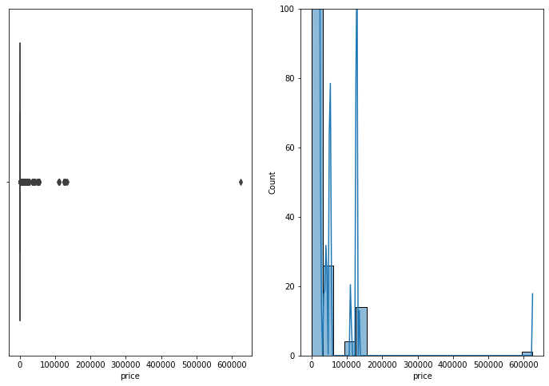

#### Antes de retirar os outliers com base no desvio padrão, será removido primeiramente valores espúrios, como por exemplo, imóveis valores acima de 10000,00.

```
120
```

### Para efeito de "validação" do dado, também serão excluídos imóveis que nunca foram avaliados

### Isto não quer dizer necessariamente que nunca foram alugados pelo Airbnb, porém pesquisando sobre a taxa de pessoas que deixam reviews no aplicativo do imóvel, quando o usam, é de mais de 50% (em fontes diferentes...tem-se 50%, 70& e até 90%...todas em períodos diferentes mas citam o Airbnb como fonte desta informação.)

```
count    16392.000000
mean       327.850537
std        304.550237
min         33.000000
25%        143.000000
50%        229.000000
75%        399.000000
max       2087.000000
Name: price, dtype: float64
```

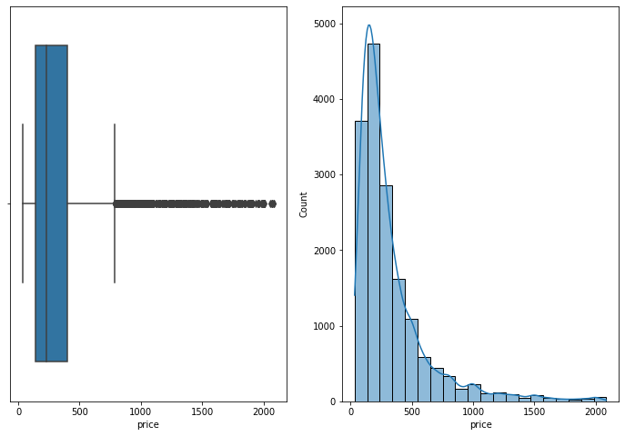

```
neighbourhood_cleansed
Abolição             595.000000
Alto da Boa Vista    482.941176
Andaraí              133.590909
Anil                 202.666667
Bancários            150.000000
Name: price, dtype: float64
```

|  | neighbourhood | neighbourhood_group | geometry | price | id |
| --- | --- | --- | --- | --- | --- |
| 132 | Copacabana | None | MULTIPOLYGON Z (((-43.17186 -22.95896 0.00000,... | 312.822344 | 5308.0 |
| 149 | Ipanema | None | MULTIPOLYGON Z (((-43.19483 -22.97744 0.00000,... | 434.433333 | 1740.0 |
| 147 | Barra da Tijuca | None | MULTIPOLYGON Z (((-43.40291 -22.97270 0.00000,... | 427.485019 | 1602.0 |
| 134 | Botafogo | None | MULTIPOLYGON Z (((-43.17827 -22.94005 0.00000,... | 268.171329 | 858.0 |
| 148 | Leblon | None | MULTIPOLYGON Z (((-43.21417 -22.98052 0.00000,... | 480.521793 | 803.0 |
| ... | ... | ... | ... | ... | ... |
| 71 | Engenheiro Leal | None | MULTIPOLYGON Z (((-43.31914 -22.87644 0.00000,... | NaN | NaN |
| 75 | Jacarezinho | None | MULTIPOLYGON Z (((-43.25309 -22.88422 0.00000,... | NaN | NaN |
| 97 | Jacaré | None | MULTIPOLYGON Z (((-43.24909 -22.89010 0.00000,... | NaN | NaN |
| 107 | Água Santa | None | MULTIPOLYGON Z (((-43.30335 -22.90463 0.00000,... | NaN | NaN |
| 157 | Caju | None | MULTIPOLYGON Z (((-43.22518 -22.87464 0.00000,... | NaN | NaN |

160 rows × 5 columns

```
neighbourhood
Vista Alegre          1326.000000
Joá                    734.480000
Sepetiba               600.000000
Abolição               595.000000
Realengo               542.000000
Complexo do Alemão     520.000000
Vargem Grande          515.837838
Guaratiba              492.891892
Alto da Boa Vista      482.941176
Leblon                 480.521793
Name: price, dtype: float64
```

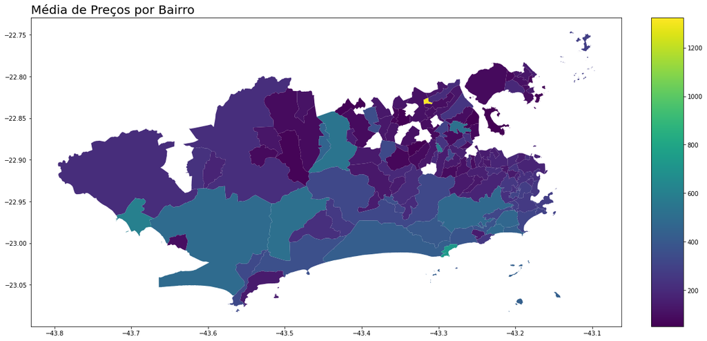

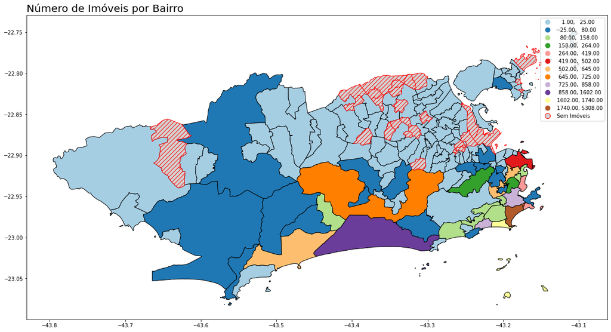

### Uma outra visualização das locações disponíveis...

#### Mapa de Calor

#### [Visualização interativa com o mouse]

[interactive chart not shown]

```
neighbourhood_cleansed
Copacabana                  5308
Ipanema                     1740
Barra da Tijuca             1602
Botafogo                     858
Leblon                       803
Jacarepaguá                  725
Recreio dos Bandeirantes     645
Santa Teresa                 575
Centro                       502
Flamengo                     419
Name: id, dtype: int64
```

```
neighbourhood
Vista Alegre          1326.000000
Joá                    734.480000
Sepetiba               600.000000
Abolição               595.000000
Realengo               542.000000
Complexo do Alemão     520.000000
Vargem Grande          515.837838
Guaratiba              492.891892
Alto da Boa Vista      482.941176
Leblon                 480.521793
Name: price, dtype: float64
```

#### Fazendo uma rápida pesquisa no Google: Joá (Bairro número 2 em preço) é um dos bairros mais exclusivos do Rio De Janeiro e verificando algumas url, realmente são casas luxuosas (quando não, mansões). Porém Vista Aeegre (O bairro na media) é um bairro na zona Norte do Rio, longe de praias e atrações turísticas . O que houve para ser o primeiro rankeado na média de preços ?

|  | listing_url | price | first_review | last_review |
| --- | --- | --- | --- | --- |
| 7943 | https://www.airbnb.com/rooms/13654995 | 1326.0 | 2016-08-05 | 2016-08-05 |

### Como é apenas um imóvel, é possível verificar pela url que é um imóvel simples (para o valor). Provavelmente um erro de input do usuário, porém como está dentro dos valores filtrado, este valor será mantido até este ponto.

|  | host_id | neighbourhood_cleansed | price | number_of_reviews | review_scores_value |
| --- | --- | --- | --- | --- | --- |
| 16666 | 7816122 | Ipanema | 2087.0 | 6 | 10.0 |
| 2802 | 15488907 | Barra da Tijuca | 2086.0 | 7 | 10.0 |
| 3941 | 13109525 | Flamengo | 2073.0 | 2 | 7.0 |
| 3732 | 25762920 | Botafogo | 2073.0 | 6 | 10.0 |
| 5492 | 3413189 | Ipanema | 2072.0 | 1 | 6.0 |
| 23717 | 251614625 | Joá | 2071.0 | 2 | 10.0 |
| 14738 | 66039372 | Copacabana | 2070.0 | 3 | 7.0 |
| 12138 | 2438594 | Copacabana | 2070.0 | 5 | 10.0 |
| 13761 | 66039372 | Ipanema | 2070.0 | 44 | 9.0 |
| 14734 | 66039372 | Copacabana | 2070.0 | 1 | 10.0 |
| 24688 | 177294579 | Leblon | 2056.0 | 1 | 10.0 |
| 15390 | 234424447 | Copacabana | 2014.0 | 6 | 9.0 |
| 23853 | 374521777 | Barra da Tijuca | 2000.0 | 2 | 9.0 |
| 11736 | 141866453 | Copacabana | 2000.0 | 2 | 9.0 |
| 19323 | 99924329 | Copacabana | 2000.0 | 1 | 10.0 |
| 6621 | 15975189 | Recreio dos Bandeirantes | 2000.0 | 4 | 10.0 |
| 23424 | 8975746 | Leblon | 2000.0 | 1 | 10.0 |
| 7802 | 77975347 | Copacabana | 2000.0 | 3 | 10.0 |
| 5518 | 53588365 | Jacarepaguá | 2000.0 | 13 | 9.0 |
| 4038 | 31143264 | Barra da Tijuca | 2000.0 | 3 | 10.0 |

```
neighbourhood_cleansed
Vista Alegre          1326.000000
Joá                    734.480000
Sepetiba               600.000000
Abolição               595.000000
Realengo               542.000000
Complexo do Alemão     520.000000
Vargem Grande          515.837838
Guaratiba              492.891892
Alto da Boa Vista      482.941176
Leblon                 480.521793
Name: price, dtype: float64
```

### O Complexo do Alemão está entre os top 10 preços de diária, a frente de Leblon, Copacabana e outros bairros. Os dados ainda apresentam inconsistências...

Checando os dados do Complexo do Alemão:

|  | price | listing_url | number_of_reviews | review_scores_value |
| --- | --- | --- | --- | --- |
| 10977 | 140.0 | https://www.airbnb.com/rooms/17148972 | 6 | 10.0 |
| 12208 | 900.0 | https://www.airbnb.com/rooms/21448656 | 1 | 10.0 |

|  | id | listing_url | scrape_id | last_scraped | name | description | neighborhood_overview | picture_url | host_id | host_url | host_name | host_since | host_location | host_response_time | host_response_rate | host_acceptance_rate | host_is_superhost | host_thumbnail_url | host_picture_url | host_neighbourhood | host_listings_count | host_total_listings_count | host_verifications | host_has_profile_pic | host_identity_verified | neighbourhood | neighbourhood_cleansed | latitude | longitude | … |
| --- | --- | --- | --- | --- | --- | --- | --- | --- | --- | --- | --- | --- | --- | --- | --- | --- | --- | --- | --- | --- | --- | --- | --- | --- | --- | --- | --- | --- | --- | --- |
| 12208 | 21448656 | https://www.airbnb.com/rooms/21448656 | 20210222161029 | 2021-02-24 | Casa 1 quarto alem | Lugar aconchegante, perfeito para quem quer um... | NaN | https://a0.muscache.com/pictures/9511c029-d1f3... | 155642978 | https://www.airbnb.com/users/show/155642978 | Felipe | 2017-10-21 | BR | NaN | NaN | NaN | f | https://a0.muscache.com/im/pictures/user/342bd... | https://a0.muscache.com/im/pictures/user/342bd... | NaN | 1.0 | 1.0 | ['email', 'phone', 'reviews'] | t | f | NaN | Complexo do Alemão | -22.86109 | -43.27705 | … |

#### Os dados acima mostram dois valores para os imóveis no Complexo do Alemão. Como são apenas 2, o valor de 900 reais não é removido, porém se tratando de um quarto compartilhado pode-se considerar o valor espúrio. O mesmo pode ocorrer para outros bairros, quando estes tiverem poucos imóveis disponíveis.

#### Verificando o anúncio do imóvel de 900 reais, pelas fotos e descrição, parece que o imóvel está disponível para um aluguel de fato, não para diárias...(o valor seria um valor referente a um alguel mensal)

#### É possível verificar esse mesmo tipo de ocorrência no bairro de Realengo também, por exemplo.

|  | price | listing_url | room_type | first_review | last_review |
| --- | --- | --- | --- | --- | --- |
| 6446 | 884.0 | https://www.airbnb.com/rooms/11871841 | Entire home/apt | 2016-07-09 | 2016-07-09 |
| 22175 | 200.0 | https://www.airbnb.com/rooms/43177523 | Entire home/apt | 2020-05-24 | 2020-05-24 |

#### Checando Padre Miguel também...

|  | price | listing_url | room_type | first_review | last_review |
| --- | --- | --- | --- | --- | --- |
| 952 | 839.0 | https://www.airbnb.com/rooms/1428202 | Entire home/apt | 2016-06-03 | 2020-09-07 |
| 13401 | 74.0 | https://www.airbnb.com/rooms/24129613 | Entire home/apt | 2020-02-29 | 2020-02-29 |

#### Visualizando a distribuição de imóveis junto com algumas métricas ou classificações

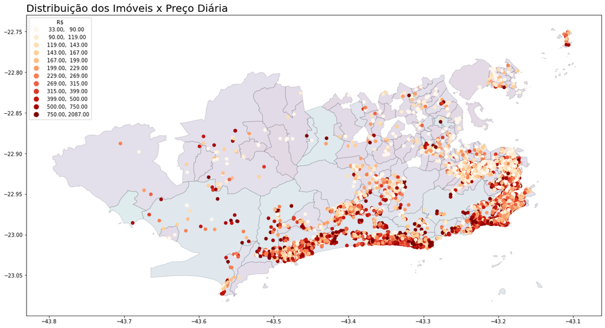

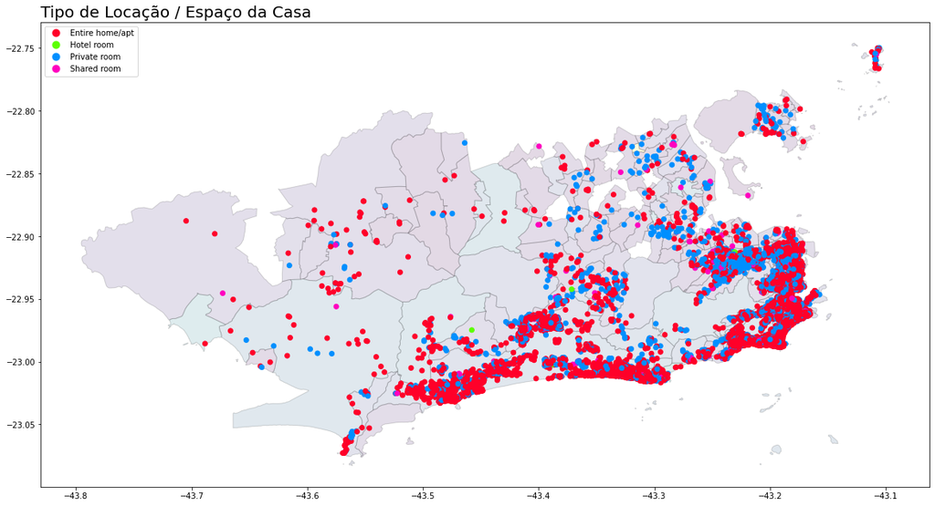

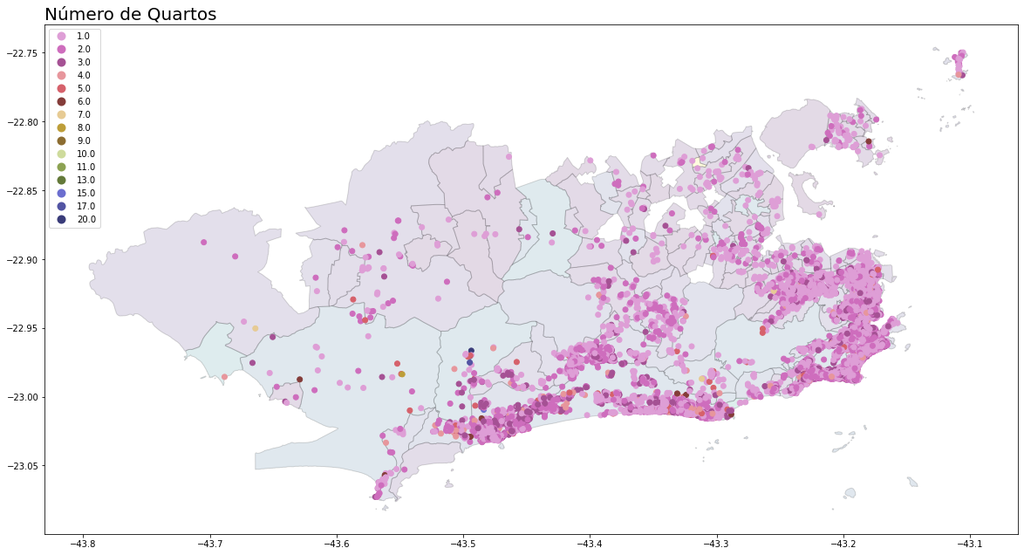

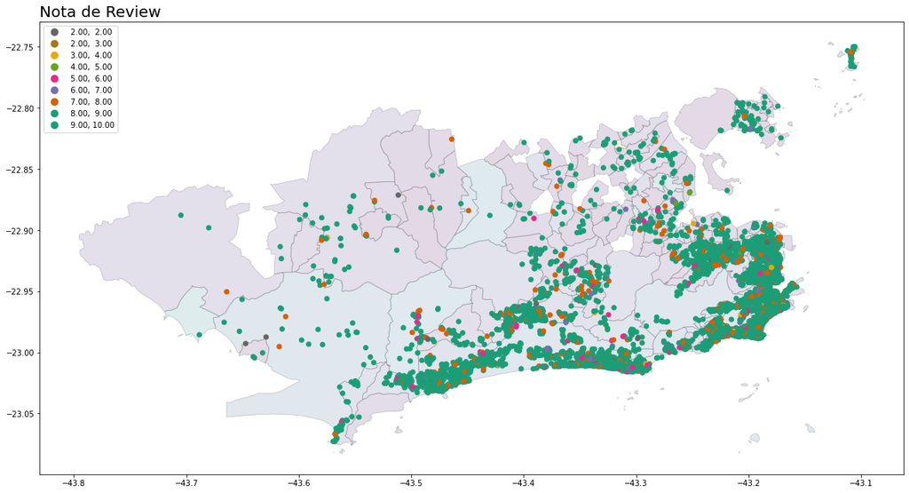

#### Analisando os mapas acima, pode-se dizer que:

- Os imóveis estão em grande parte localizados nas regiões próximos à praia, principalmente na zona Sul Carioca
- Grande maioria são imóveis com poucos quartos (de 1 a 3)
- A maior parte dos imóveis ofertados são do tipo "Casa/Apartamento Inteiro", seguido de quarto privado
- Imensa maioria dos imóveis são bem avaliados com notas a partir de 8.

- Os imóveis estão mais localizados na Zona Sul, Barra da Tijuca , Tijuca e Centro.
- As zonas da Barra da Tijuca e Zona Sul são conhecidas por serem mais nobres, o que explica os preços elevados nesta região (mapa 1 - Distribuição dos Imóveis por Preço)

### Agora será criada uma lista com todos os itens existentes no dataset, sabendo desta forma a variedade de itens e verificar se há necessidade de mais filtros e quais itens podem ser relevantes...

- Strings com NetFlix serão apenas 'NetFlix'
- Strings com Wi-fi serão apenas WiFi
- Strings com Refrigerator serão apenas refrigerators

# Calendar

[output not shown]

[output not shown]

[output not shown]